# Stock Analysis with PerformanceAnalytics

jy

2023-01-16

## Intro

Examples of return and portfolio analysis that can be done with the PerformanceAnalytics package.

- (Performance Analytics pkg manual)[https://cran.r-project.org/web/packages/PerformanceAnalytics/PerformanceAnalytics.pdf]
- (Blog post: Performance Analytics: An Indispensable Quant Tool for Any Investor)[https://franklinparker.com/2019/02/16/performanceanalytics-an-indespensible-quant-tool-for-any-investor/]

## Get Data

Select 3 ETFs to compare for the purpose of selection.

```r
etf_symbols <- c("^GSPC","VTI","VIG","ZLB.TO")
## set empty object
etf_all <- NULL
## loop through each stock, binding cols as you go
for(stocks in etf_symbols){
  etf_all <- cbind(etf_all,
                      getSymbols(Symbols=stocks,
                                 from='2018-01-01', periodicity='daily',
                                 auto.assign = FALSE))
}
head(etf_all)
```

```
##            GSPC.Open GSPC.High GSPC.Low GSPC.Close GSPC.Volume GSPC.Adjusted
## 2018-01-02   2683.73   2695.89  2682.36    2695.81  3397430000       2695.81
## 2018-01-03   2697.85   2714.37  2697.77    2713.06  3544030000       2713.06
## 2018-01-04   2719.31   2729.29  2719.07    2723.99  3697340000       2723.99
## 2018-01-05   2731.33   2743.45  2727.92    2743.15  3239280000       2743.15
## 2018-01-08   2742.67   2748.51  2737.60    2747.71  3246160000       2747.71
## 2018-01-09   2751.15   2759.14  2747.86    2751.29  3467460000       2751.29
##            VTI.Open VTI.High VTI.Low VTI.Close VTI.Volume VTI.Adjusted VIG.Open
## 2018-01-02   137.75   138.23  137.44    138.22    3699700     126.9705   102.36
## 2018-01-03   138.39   139.10  138.30    139.02    3052300     127.7054   102.55
## 2018-01-04   139.42   139.81  139.35    139.55    2572400     128.1923   103.16
## 2018-01-05   140.02   140.44  139.72    140.37    2188500     128.9456   103.67
## 2018-01-08   140.31   140.77  140.10    140.69    2655300     129.2395   104.03
## 2018-01-09   140.92   141.31  140.71    140.95    2625200     129.4783   104.46
##            VIG.High VIG.Low VIG.Close VIG.Volume VIG.Adjusted ZLB.TO.Open
## 2018-01-02   102.46  102.13    102.39     881200     93.17175       30.61
## 2018-01-03   102.90  102.39    102.86    1218200     93.59945       30.52
## 2018-01-04   103.48  103.15    103.25    1757800     93.95434       30.44
## 2018-01-05   104.05  103.55    104.02     750900     94.65501       30.40
## 2018-01-08   104.37  103.77    104.32     829600     94.92800       30.38
## 2018-01-09   104.92  104.40    104.66     754700     95.23740       30.37
##            ZLB.TO.High ZLB.TO.Low ZLB.TO.Close ZLB.TO.Volume ZLB.TO.Adjusted
## 2018-01-02       30.61      30.45        30.50         31400        26.88730
## 2018-01-03       30.55      30.44        30.44         57100        26.83440
## 2018-01-04       30.50      30.40        30.40         57300        26.79914
## 2018-01-05       30.40      30.30        30.33         53800        26.73743
## 2018-01-08       30.38      30.25        30.31         70600        26.71980
## 2018-01-09       30.37      30.26        30.29         63100        26.70217
```

### Initial viz

```r
dygraph(Cl(etf_all))
```

[interactive chart not shown]

- with S&P 500 removed

```r
etf_nosp <- etf_all[,7:ncol(etf_all)]
dygraph(Cl(etf_nosp))
```

[interactive chart not shown]

## Get Returns

Performance Analytics focuses on returns analysis. From the manual:

*“Performance measurement starts with returns… Most of the recent work in performance analysis is focused on returns rather than prices and sometimes called”returns-based analysis” or RBA. This “price per unit of investment” standardization is important for two reasons - first, it helps the decision maker to compare opportunities, and second, it has some useful statistical qualities.”*

```r
## monthly returns
## 1. convert time series to monthly OHLC
## - doesn't convert the whole set at once - need to do each symbol individually
## - need to use symbols for col names, otherwise will mangle them, even though already there
etf_all_mth <- NULL
etf_all_mth_ret <- NULL
for(i in 1:length(etf_symbols)){
  cstart <- i*6-5
  cend <- cstart+5
  etf_mth <- to.monthly(etf_all[,cstart:cend], name=etf_symbols[i])
  etf_all_mth <- cbind(etf_all_mth, etf_mth)
  #etf_mth_ret <- Return.calculate(etf_mth)
  #etf_all_mth_ret <- cbind(etf_all_mth_ret, etf_mth_ret)
}
## 2. calc returns on monthly prices
## - gets returns for all cols
etf_mth_ret <- Return.calculate(etf_all_mth)
```

## Correlations

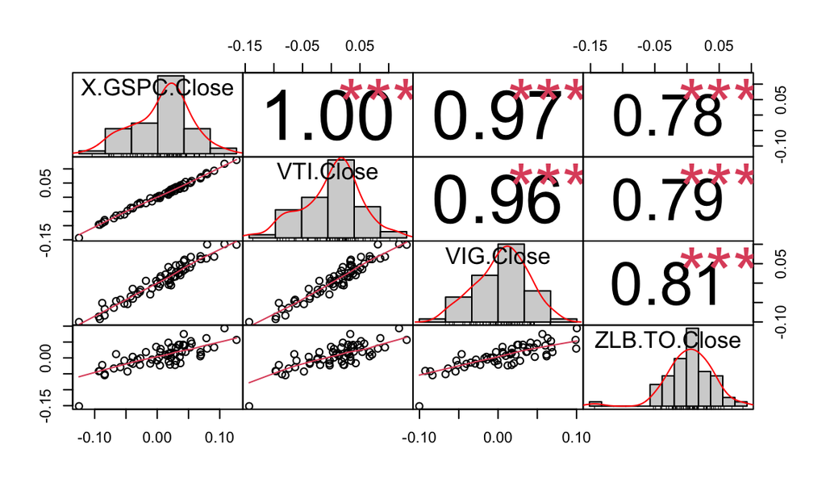

```r
## get Close cols
cols <- which(str_detect(colnames(etf_mth_ret), "Close"))
etf_mth_ret_cl <- etf_mth_ret[,cols]
## convert to data frame
etf_mth_ret_df <- data.frame(etf_mth_ret_cl)
## correlation chart
chart.Correlation(etf_mth_ret_df)
```

From (Performance Analytics: An Indispensable Quant Tool for Any Investor)[https://franklinparker.com/2019/02/16/performanceanalytics-an-indespensible-quant-tool-for-any-investor/]

“The diagonal gives you the return distribution of each ETF. I like to see how the returns are distributed—are the concentrated in the center? are there lots of outliers? are they heavily skewed? is something just weird? Indeed, this plot recently helped me immediately throw out a position under consideration because the distribution was barbelled (but more heavy left-tailed).”

## Upside/Downside Capture

Not actually sure how to interpret.

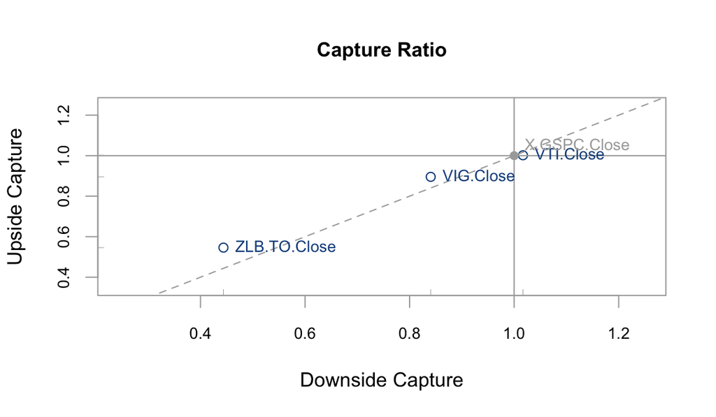

```r
chart.CaptureRatios(Ra=etf_mth_ret_cl[,2:4], Rb=etf_mth_ret_cl[,"X.GSPC.Close"], colorset="dodgerblue4",
    main="Capture Ratio")
```

## Distribution of Returns

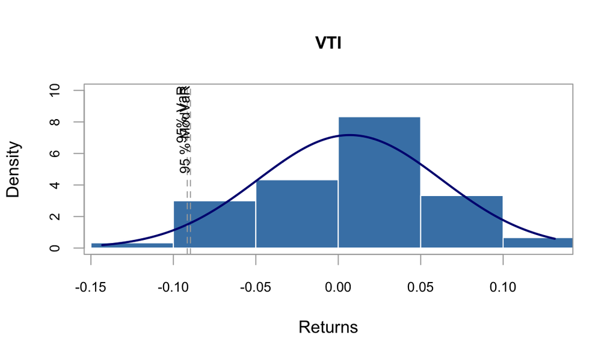

```r
sel <- 2
chart.Histogram(etf_mth_ret_df[,sel],
                methods=c("add.normal","add.risk"),
                colorset = c('steelblue','','navyblue'),
                main=etf_symbols[sel])
```

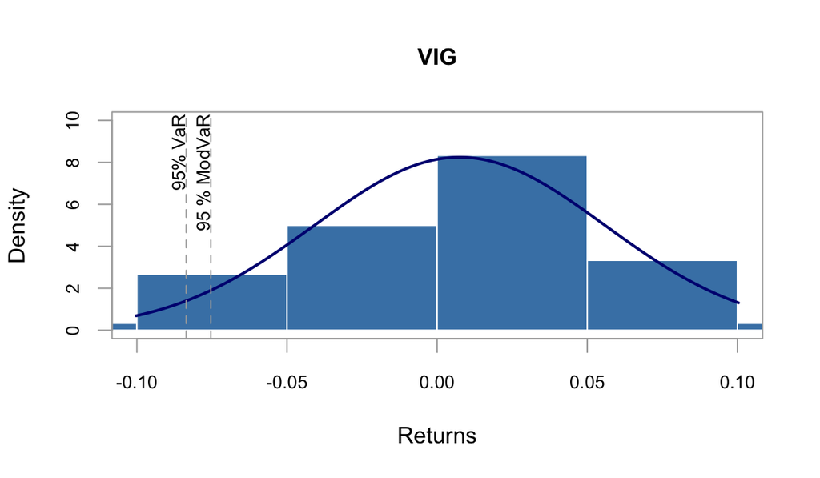

```r
sel <- 3
chart.Histogram(etf_mth_ret_df[,sel],
                methods=c("add.normal","add.risk"),
                colorset = c('steelblue','','navyblue'),
                main=etf_symbols[sel])
```

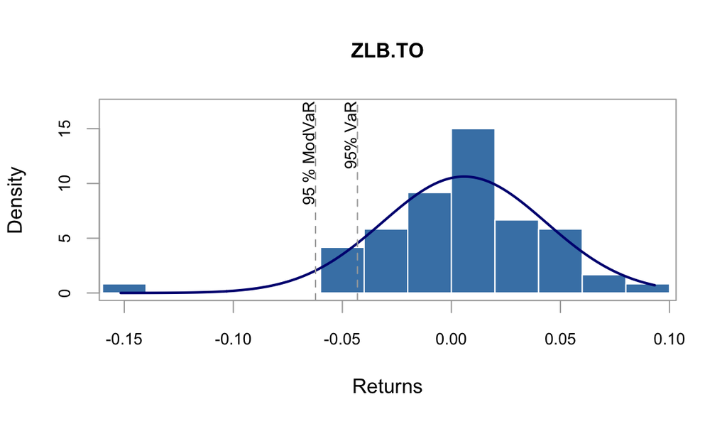

```r
sel <- 4
chart.Histogram(etf_mth_ret_df[,sel],
                methods=c("add.normal","add.risk"),
                colorset = c('steelblue','','navyblue'),
                main=etf_symbols[sel])
```

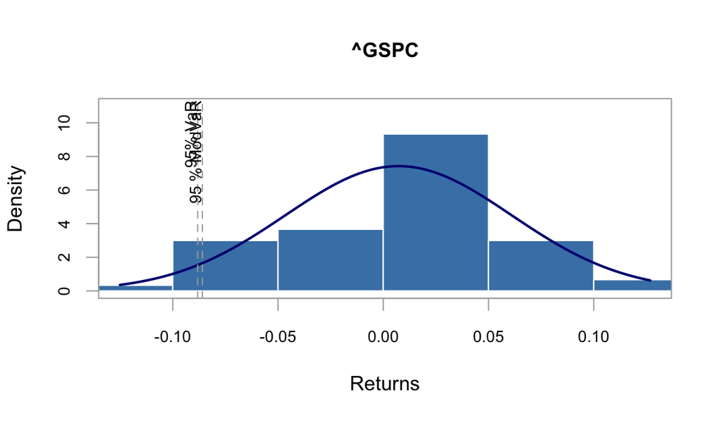

```r
sel <- 1
chart.Histogram(etf_mth_ret_df[,sel],
                methods=c("add.normal","add.risk"),
                colorset = c('steelblue','','navyblue'),
                main=etf_symbols[sel])
```

## Drawdown comparisons

Shows how resilient investment is during negative return situations.

```r
#sel <- 1
#chart.Drawdown(etf_mth_ret_cl[,sel], geometric=TRUE, colorset="firebrick4", main=etf_symbols[sel])
## plot.engine options: ggplot2, plotly, dygraph, googlevis, default
chart.Drawdown(etf_mth_ret_cl, geometric=TRUE, legend.loc='bottomleft', plot.engine="dygraph")
```

[interactive chart not shown]